# Zotero group ILK

Published

28 November 2026

Zotero data of 28 November 2026 · IPBES Literature Report 0.7.0 · [source code on GitHub](https://github.com/IPBES-Data/IPBES.LiteratureReport)

This report shows the state of the Zotero group **ILK** ([open the group in Zotero](https://www.zotero.org/groups/2344322)). It gives an overview of the literature in the group, and lists the items which should be corrected.

Each item in the lists can be opened in the Zotero **web** library or in the Zotero **app** on your computer, so that it can be corrected directly. Corrected items disappear from the lists the next time the report is updated. Some checks compare the items with [OpenAlex](https://openalex.org), an open catalogue of scholarly publications.

## Summary

[output not shown]

**Please fix**: these items contain errors. **Please check**: these items may need a correction. **For information**: no action needed unless the group uses this, e.g. tags.

## Items to fix

The lists are sorted by importance. Use the search field above a list to find an item. **web** opens the item in the Zotero web library, **app** in the Zotero app.

### Retracted publications

These publications have been retracted. Check whether they should still be cited, and mark or remove them in Zotero.

**✔ Nothing to fix.**

### DOI points to a different publication

The DOI of these items leads to a publication with a different title or year. Usually the DOI is wrong: open the DOI to see where it leads, and correct it in Zotero. If the titles match and only the year differs, the DOI is probably right and the date in Zotero wrong (unless it is a reprint or another edition): correct the date instead. Differences of one year (e.g. published online before print) are not listed.

If the DOI is right although title or year differ (e.g. a book chapter with the DOI of the whole book, or a wrong year in OpenAlex), add the line `DOI checked: correct` to Extra: the item is then no longer listed (the Zotero plugin offers this as “Keep as it is”).

| Open in Zotero | Title in Zotero | Year in Zotero | The DOI leads to | Its year | DOI |
| --- | --- | --- | --- | --- | --- |
| <a href="https://www.zotero.org/groups/2344322/items/CA9FZXNG" target="_blank">web</a> &middot; <a href="zotero://select/groups/2344322/items/CA9FZXNG">app</a> | Agricultura Tradicional y riqueza de maíces (Zea mays). estudio de Caso en Caspalá, provincia de Jujuy, Argentina [Traditional agriculture and the richness of maize (Zea mays). A case study in Caspalá… | 1970 | Agricultura Tradicional y riqueza de maíces (Zea mays). estudio de Caso en Caspalá, provincia de Jujuy, Argentina | 2013 | <a href="https://doi.org/10.31055/1851.2372.v48.n3-4.7623" target="_blank">10.31055/1851.2372.v48.n3-4.7623</a> |
| <a href="https://www.zotero.org/groups/2344322/items/VZS76VBG" target="_blank">web</a> &middot; <a href="zotero://select/groups/2344322/items/VZS76VBG">app</a> | The Negotiations Web: Complex Connections | 2012 | The Future Control of Food | 2012 | <a href="https://doi.org/10.4324/9781849773027" target="_blank">10.4324/9781849773027</a> |
| <a href="https://www.zotero.org/groups/2344322/items/8EDMFMJU" target="_blank">web</a> &middot; <a href="zotero://select/groups/2344322/items/8EDMFMJU">app</a> | Democratic decentralisation in the forestry sector: Lessons learned from Africa, Asia and Latin America | 2005 | The Politics of Decentralization | 2012 | <a href="https://doi.org/10.4324/9781849773218" target="_blank">10.4324/9781849773218</a> |
| <a href="https://www.zotero.org/groups/2344322/items/XMNSFQLS" target="_blank">web</a> &middot; <a href="zotero://select/groups/2344322/items/XMNSFQLS">app</a> | The paradox of poverty in rich ecosystems: impoverishment and development in the Amazon of Brazil and Bolivia | 2016 | The paradox of poverty in rich ecosystems: impoverishment and development in the A mazon of B razil and B olivia | 2014 | <a href="https://doi.org/10.1111/geoj.12124" target="_blank">10.1111/geoj.12124</a> |
| <a href="https://www.zotero.org/groups/2344322/items/U75H349U" target="_blank">web</a> &middot; <a href="zotero://select/groups/2344322/items/U75H349U">app</a> | Selective-logging and oil palm: Multitaxon impacts, biodiversity indicators, and trade-offs for conservation planning | 2014 | Averting biodiversity collapse in tropical forest protected areas | 2012 | <a href="https://doi.org/10.1038/nature11318" target="_blank">10.1038/nature11318</a> |
| <a href="https://www.zotero.org/groups/2344322/items/DXD7LYJY" target="_blank">web</a> &middot; <a href="zotero://select/groups/2344322/items/DXD7LYJY">app</a> | Biocultural diversity should be a priority for conservation | 2008 | Key discoveries often originate with lone researchers | 2008 | <a href="https://doi.org/10.1038/456315a" target="_blank">10.1038/456315a</a> |
| <a href="https://www.zotero.org/groups/2344322/items/KAS85G2L" target="_blank">web</a> &middot; <a href="zotero://select/groups/2344322/items/KAS85G2L">app</a> | Applying indigenous knowledge to the restoration of degraded tropical rain forest clearings dominated by bracken fern | 2010 | Applying Indigenous Knowledge to the Restoration of Degraded Tropical Rain Forest Clearings Dominated by Bracken Fern | 2008 | <a href="https://doi.org/10.1111/j.1526-100x.2008.00459.x" target="_blank">10.1111/j.1526-100x.2008.00459.x</a> |
| <a href="https://www.zotero.org/groups/2344322/items/7FFXHSPD" target="_blank">web</a> &middot; <a href="zotero://select/groups/2344322/items/7FFXHSPD">app</a> | Promises and realities of community-based pasture management approaches: Observations from Kyrgyzstan | 2011 | Promises and realities of community-based pasture management approaches: Observations from Kyrgyzstan | 2015 | <a href="https://doi.org/10.1186/s13570-015-0035-8" target="_blank">10.1186/s13570-015-0035-8</a> |
| <a href="https://www.zotero.org/groups/2344322/items/QEMY57MT" target="_blank">web</a> &middot; <a href="zotero://select/groups/2344322/items/QEMY57MT">app</a> | Endemic freshwater finfish of Asia: Distribution and conservation status: Biodiversity research | 2007 | Endemic freshwater finfish of Asia: distribution and conservation status | 2007 | <a href="https://doi.org/10.1111/j.1472-4642.2006.00311.x" target="_blank">10.1111/j.1472-4642.2006.00311.x</a> |
| <a href="https://www.zotero.org/groups/2344322/items/JYLW5Z3I" target="_blank">web</a> &middot; <a href="zotero://select/groups/2344322/items/JYLW5Z3I">app</a> | Conserving dryland biodiversity | 2012 | Conserving dryland biodiversity | 2014 | <a href="https://doi.org/10.1080/14888386.2014.942752" target="_blank">10.1080/14888386.2014.942752</a> |

[output cut: 273 more lines]

### Items which are in the group more than once

These items are in the group more than once, with the same DOI, or with the same title, year and first author. Keep one copy and merge or delete the others, e.g. with *Duplicate Items* in the Zotero app.

| Open in Zotero | Title | Copies |
| --- | --- | --- |
| <a href="https://www.zotero.org/groups/2344322/items/5CFGDZD9" target="_blank">web</a> &middot; <a href="zotero://select/groups/2344322/items/5CFGDZD9">app</a><br><a href="https://www.zotero.org/group… | Community Natural Resource Management: Promise, Rhetoric, and Reality | 2 |
| <a href="https://www.zotero.org/groups/2344322/items/HPHUZN5U" target="_blank">web</a> &middot; <a href="zotero://select/groups/2344322/items/HPHUZN5U">app</a><br><a href="https://www.zotero.org/group… | Traditional Ecological Knowledge of Swiss Alpine Farmers and their Resilience to Socioecological Change | 2 |
| <a href="https://www.zotero.org/groups/2344322/items/KHPWGR4D" target="_blank">web</a> &middot; <a href="zotero://select/groups/2344322/items/KHPWGR4D">app</a><br><a href="https://www.zotero.org/group… | Indigenous Peoples and Biodiversity | 2 |
| <a href="https://www.zotero.org/groups/2344322/items/Q2U3BLTV" target="_blank">web</a> &middot; <a href="zotero://select/groups/2344322/items/Q2U3BLTV">app</a><br><a href="https://www.zotero.org/group… | The traditional knowledge on stingless bees (Apidae: Meliponina) used by the Enawene-Nawe tribe in western Brazil | 2 |
| <a href="https://www.zotero.org/groups/2344322/items/9EN7ZUUK" target="_blank">web</a> &middot; <a href="zotero://select/groups/2344322/items/9EN7ZUUK">app</a><br><a href="https://www.zotero.org/group… | The Age of Australian Rock Art: A Review | 2 |
| <a href="https://www.zotero.org/groups/2344322/items/TVG6JSWB" target="_blank">web</a> &middot; <a href="zotero://select/groups/2344322/items/TVG6JSWB">app</a><br><a href="https://www.zotero.org/group… | The Local Perception of Tropical Deforestation and its Relation to Conservation Policies in Los Tuxtlas Biosphere Reserve, Mexico | 2 |
| <a href="https://www.zotero.org/groups/2344322/items/FGCMAIUW" target="_blank">web</a> &middot; <a href="zotero://select/groups/2344322/items/FGCMAIUW">app</a><br><a href="https://www.zotero.org/group… | Bridging the gap between forest conservation and poverty alleviation: The Ecuadorian Socio Bosque program | 2 |
| <a href="https://www.zotero.org/groups/2344322/items/EC8CSDKI" target="_blank">web</a> &middot; <a href="zotero://select/groups/2344322/items/EC8CSDKI">app</a><br><a href="https://www.zotero.org/group… | Water, Cultural Diversity, and Global Environmental Change | 2 |
| <a href="https://www.zotero.org/groups/2344322/items/INFM2VS4" target="_blank">web</a> &middot; <a href="zotero://select/groups/2344322/items/INFM2VS4">app</a><br><a href="https://www.zotero.org/group… | Working Knowledge: Characterising collective indigenous, scientific, and local knowledge about the ecology, hydrology and geomorphology of Oriners station, cape york Peninsula, Australia | 2 |
| <a href="https://www.zotero.org/groups/2344322/items/647PCPNP" target="_blank">web</a> &middot; <a href="zotero://select/groups/2344322/items/647PCPNP">app</a><br><a href="https://www.zotero.org/group… | Transiciones hacia el vivir bien, o la construcción de un nuevo proyecto político en el estado plurinacional de bolivia | 4 |

[output cut: 119 more lines]

### DOI field with an invalid DOI

The DOI field of these items contains something which is not a valid DOI. Correct or remove it.

| Open in Zotero | Title | Content of the DOI field |
| --- | --- | --- |
| <a href="https://www.zotero.org/groups/2344322/items/S9Z6IE7Q" target="_blank">web</a> &middot; <a href="zotero://select/groups/2344322/items/S9Z6IE7Q">app</a> | CONSERVING LOCAL KNOWLEDGE IN TRADITIONAL HEALING THROUGH KNOWLEDGE TRANSFER | 10.1051/ |
| <a href="https://www.zotero.org/groups/2344322/items/5DCFXR2I" target="_blank">web</a> &middot; <a href="zotero://select/groups/2344322/items/5DCFXR2I">app</a> | Indigenous knowledge of Lepcha community for monitoring and conservation of birds | http://nopr.niscpr.res.in/handle/123456789/2968 |
| <a href="https://www.zotero.org/groups/2344322/items/3DMUG2QT" target="_blank">web</a> &middot; <a href="zotero://select/groups/2344322/items/3DMUG2QT">app</a> | INDIGENOUS CHALLENGES TO ENHANCE FRESHWATER GOVERNANCE AND MANAGEMENT IN AOTEAROA NEW ZEALAND ± THE WAIKATO RIVER SETTLEMENT | https://hdl.handle.net/10289/5705 |
| <a href="https://www.zotero.org/groups/2344322/items/CC2WQCCV" target="_blank">web</a> &middot; <a href="zotero://select/groups/2344322/items/CC2WQCCV">app</a> | Effect of Traditional Management Practices on Woody Species Composition and Structure in Montane Subtropical Forests of Meghalaya, Northeast India | 10.100 |
| <a href="https://www.zotero.org/groups/2344322/items/X9JM5D5K" target="_blank">web</a> &middot; <a href="zotero://select/groups/2344322/items/X9JM5D5K">app</a> | Indigenous Cosmopolitics in the Andes: Conceptual Reflections Beyond 'Politics' | 10.14506/ |
| <a href="https://www.zotero.org/groups/2344322/items/D9SJLJJQ" target="_blank">web</a> &middot; <a href="zotero://select/groups/2344322/items/D9SJLJJQ">app</a> | Prevalence of suicidal behaviour among indigenous Sami in northern Norway | 10.3402/ |
| <a href="https://www.zotero.org/groups/2344322/items/3BRM3AVK" target="_blank">web</a> &middot; <a href="zotero://select/groups/2344322/items/3BRM3AVK">app</a> | Agroecology and Food Sovereignty | Article |
| <a href="https://www.zotero.org/groups/2344322/items/D2I8WNNU" target="_blank">web</a> &middot; <a href="zotero://select/groups/2344322/items/D2I8WNNU">app</a> | Development of a GIS for Global Biocultural Diversity | Policy Matters |
| <a href="https://www.zotero.org/groups/2344322/items/6QL9BGS2" target="_blank">web</a> &middot; <a href="zotero://select/groups/2344322/items/6QL9BGS2">app</a> | Adapting to Climate Change: Social-Ecological Relilience in a Canadian Western Arctic Community | 18 |
| <a href="https://www.zotero.org/groups/2344322/items/MY39QJXC" target="_blank">web</a> &middot; <a href="zotero://select/groups/2344322/items/MY39QJXC">app</a> | Fish Consumption, Fish Lore, and Mercury PollutionNRisk Communication for the Madeira River People | 10.1006 |

[output cut: 3 more lines]

### DOI which does not exist

The DOI of these items does not exist at doi.org: usually a typo, a shortened DOI, or a DOI with extra characters at the end. Where the DOI without these characters exists, it is given as suggestion. Otherwise find the right DOI, or remove it (then the search by title in OpenAlex can offer one).

| Open in Zotero | Title | Content of the DOI field | Suggestion |
| --- | --- | --- | --- |
| <a href="https://www.zotero.org/groups/2344322/items/JKEVQQGK" target="_blank">web</a> &middot; <a href="zotero://select/groups/2344322/items/JKEVQQGK">app</a> | Indigenous Knowledge and Sea Ice Science: What Can We Learn from Indigenous Ice Users? | 10.1007/978-90-481-8587 |  |
| <a href="https://www.zotero.org/groups/2344322/items/3BAATZM9" target="_blank">web</a> &middot; <a href="zotero://select/groups/2344322/items/3BAATZM9">app</a> | Indigenous Agroforestry Systems of Ifugao , Philippines | 10.5923/j.re.20150501.04 |  |
| <a href="https://www.zotero.org/groups/2344322/items/PK6SPPVY" target="_blank">web</a> &middot; <a href="zotero://select/groups/2344322/items/PK6SPPVY">app</a> | Comparative Analysis of Access and Benefit Sharing Regimes in India and Russia in Context of Indigenous People and Local Communities | 10.17516/1997-1370-2016-9-1-265-290.Research |  |
| <a href="https://www.zotero.org/groups/2344322/items/ZU883DE8" target="_blank">web</a> &middot; <a href="zotero://select/groups/2344322/items/ZU883DE8">app</a> | Who Owns Traditional Knowledge? | 10.2307/4414163 |  |
| <a href="https://www.zotero.org/groups/2344322/items/KD525X9T" target="_blank">web</a> &middot; <a href="zotero://select/groups/2344322/items/KD525X9T">app</a> | Biocultural Diversity : Moving beyond the Realm of ' Indigenous ' and ' Local ' People Author ( s ): Michelle Cocks Stable URL : http://www.jstor.org/stable/27654114 Biocultural Diversity : Moving Bey… | 10.1007/sl0745-006-9013-5 |  |
| <a href="https://www.zotero.org/groups/2344322/items/EVDTNERH" target="_blank">web</a> &middot; <a href="zotero://select/groups/2344322/items/EVDTNERH">app</a> | Internally Motivated Development Projects: A Potential Tool for Biodiversity Conservation outside of Protected Areas | 10.2307/4314718 |  |
| <a href="https://www.zotero.org/groups/2344322/items/LZ5C4IIZ" target="_blank">web</a> &middot; <a href="zotero://select/groups/2344322/items/LZ5C4IIZ">app</a> | Indigenous Peoples and Conservation | 10.2307/2386442 |  |
| <a href="https://www.zotero.org/groups/2344322/items/CXY4FMPV" target="_blank">web</a> &middot; <a href="zotero://select/groups/2344322/items/CXY4FMPV">app</a> | Assessment of community-based restoration of Pichavaram mangrove wetland using remote sensing data | 10.2307/24109889 |  |
| <a href="https://www.zotero.org/groups/2344322/items/GGEJZ5HR" target="_blank">web</a> &middot; <a href="zotero://select/groups/2344322/items/GGEJZ5HR">app</a> | Commercialization of non-timber forest products in Ghana: Processing, packaging and marketing | https://doi.org/10.1234/4.2010.1884 |  |
| <a href="https://www.zotero.org/groups/2344322/items/JE42LMWS" target="_blank">web</a> &middot; <a href="zotero://select/groups/2344322/items/JE42LMWS">app</a> | Contextualising Learning through the Participatory Construction of an Environmental Education Programme | 10.1080/09500690903203135> | <a href="https://doi.org/10.1080/09500690903203135" target="_blank">10.1080/09500690903203135</a> |

[output cut: 18 more lines]

### DOI field with a link or prefix instead of the DOI

The DOI field of these items contains the DOI as a link (`https://doi.org/…`) or with a prefix (`DOI …`). Citation styles add the link themselves, so it would appear twice. Replace it with the DOI only.

| Open in Zotero | Title | Content of the DOI field | DOI |
| --- | --- | --- | --- |
| <a href="https://www.zotero.org/groups/2344322/items/A6Z38IBA" target="_blank">web</a> &middot; <a href="zotero://select/groups/2344322/items/A6Z38IBA">app</a> | The role of biological soil crusts in soil moisture dynamics in two semiarid ecosystems with contrasting soil textures | http://dx.doi.org/10.1016/j.jhydrol.2013.02.051 | <a href="https://doi.org/10.1016/j.jhydrol.2013.02.051" target="_blank">10.1016/j.jhydrol.2013.02.051</a> |
| <a href="https://www.zotero.org/groups/2344322/items/PHYI85JL" target="_blank">web</a> &middot; <a href="zotero://select/groups/2344322/items/PHYI85JL">app</a> | Assessing biological invasions in European Seas: Biological traits of the most widespread non-indigenous species | http://dx.doi.org/10.1016/j.ecss.2016.02.014 | <a href="https://doi.org/10.1016/j.ecss.2016.02.014" target="_blank">10.1016/j.ecss.2016.02.014</a> |
| <a href="https://www.zotero.org/groups/2344322/items/FNEU2YL2" target="_blank">web</a> &middot; <a href="zotero://select/groups/2344322/items/FNEU2YL2">app</a> | The AMMA-CATCH experiment in the cultivated Sahelian area of south-west Niger - Investigating water cycle response to a fluctuating climate and changing environment | DOI 10.1016/j.jhydrol.2009.06.021 | <a href="https://doi.org/10.1016/j.jhydrol.2009.06.021" target="_blank">10.1016/j.jhydrol.2009.06.021</a> |
| <a href="https://www.zotero.org/groups/2344322/items/WU2DSDDQ" target="_blank">web</a> &middot; <a href="zotero://select/groups/2344322/items/WU2DSDDQ">app</a> | The conservation value of high elevation habitats to North American migrant birds | http://dx.doi.org/10.1016/j.biocon.2015.10.008 | <a href="https://doi.org/10.1016/j.biocon.2015.10.008" target="_blank">10.1016/j.biocon.2015.10.008</a> |
| <a href="https://www.zotero.org/groups/2344322/items/FQNXF5RC" target="_blank">web</a> &middot; <a href="zotero://select/groups/2344322/items/FQNXF5RC">app</a> | Rangeland Degradation, Poverty, and Conflict: How Can Rangeland Scientists Contribute to Effective Responses and Solutions? | http://dx.doi.org/10.2111/REM-D-11-00155.1 | <a href="https://doi.org/10.2111/REM-D-11-00155.1" target="_blank">10.2111/REM-D-11-00155.1</a> |
| <a href="https://www.zotero.org/groups/2344322/items/C2CAB2VS" target="_blank">web</a> &middot; <a href="zotero://select/groups/2344322/items/C2CAB2VS">app</a> | Incorporating fishermen&apos;s local knowledge and behavior into Geographic Information Systems (GIS) for designing marine protected areas in Oceania | http://dx.doi.org/10.1108/17506200710779521 | <a href="https://doi.org/10.1108/17506200710779521" target="_blank">10.1108/17506200710779521</a> |
| <a href="https://www.zotero.org/groups/2344322/items/F5WEDCHF" target="_blank">web</a> &middot; <a href="zotero://select/groups/2344322/items/F5WEDCHF">app</a> | Modelling spatial variability and uncertainty of cadmium leaching to groundwater in an urban region | DOI 10.1016/j.jhydrol.2009.02.022 | <a href="https://doi.org/10.1016/j.jhydrol.2009.02.022" target="_blank">10.1016/j.jhydrol.2009.02.022</a> |
| <a href="https://www.zotero.org/groups/2344322/items/R4JZGI25" target="_blank">web</a> &middot; <a href="zotero://select/groups/2344322/items/R4JZGI25">app</a> | Rights of Nature, Legal Personality, and Indigenous Philosophies | https://doi.org/10.1017/S2047102520000217 | <a href="https://doi.org/10.1017/S2047102520000217" target="_blank">10.1017/S2047102520000217</a> |
| <a href="https://www.zotero.org/groups/2344322/items/4XUACSMK" target="_blank">web</a> &middot; <a href="zotero://select/groups/2344322/items/4XUACSMK">app</a> | Of kin and system: Rights of nature and the UN search for Earth jurisprudence | https://doi. org/10.1111/tran.12538 | <a href="https://doi.org/10.1111/tran.12538" target="_blank">10.1111/tran.12538</a> |
| <a href="https://www.zotero.org/groups/2344322/items/VEUNA782" target="_blank">web</a> &middot; <a href="zotero://select/groups/2344322/items/VEUNA782">app</a> | Indigenous economic development and well-being in a place-based context | https://doi.org/10.1787/bf4514b6-en. | <a href="https://doi.org/10.1787/bf4514b6-en" target="_blank">10.1787/bf4514b6-en</a> |

[output cut: 59 more lines]

### ISSN not in the standard form

The ISSN field of these items is not in the standard form `1234-567X` (several separated by “,”), or contains something which is not a valid ISSN, e.g. an ISBN.

| Open in Zotero | Title | Content of the ISSN field | Standard form | Not a valid ISSN |
| --- | --- | --- | --- | --- |
| <a href="https://www.zotero.org/groups/2344322/items/MYLQ4IU3" target="_blank">web</a> &middot; <a href="zotero://select/groups/2344322/items/MYLQ4IU3">app</a> | The Llanos: A Neglected Grazing Resource | 0022409X | 0022-409X | NA |
| <a href="https://www.zotero.org/groups/2344322/items/ZSQBX8GZ" target="_blank">web</a> &middot; <a href="zotero://select/groups/2344322/items/ZSQBX8GZ">app</a> | Cultural and Spiritual Values of Biodiversity | 13520237 | 1352-0237 | NA |
| <a href="https://www.zotero.org/groups/2344322/items/QLYTY6R3" target="_blank">web</a> &middot; <a href="zotero://select/groups/2344322/items/QLYTY6R3">app</a> | Nuevas narrativas constitucionales en Bolivia y Ecuador: el buen vivir y los derechos de la naturaleza | 16658574 | 1665-8574 | NA |
| <a href="https://www.zotero.org/groups/2344322/items/H6SNYC9R" target="_blank">web</a> &middot; <a href="zotero://select/groups/2344322/items/H6SNYC9R">app</a> | Participatory research supporting community-based fishery management | 0308597X | 0308-597X | NA |
| <a href="https://www.zotero.org/groups/2344322/items/PCJGE8LL" target="_blank">web</a> &middot; <a href="zotero://select/groups/2344322/items/PCJGE8LL">app</a> | Ecosystem-based adaptation for smallholder farmers: Definitions, opportunities and constraints | 01678809 | 0167-8809 | NA |
| <a href="https://www.zotero.org/groups/2344322/items/5EEKVAZE" target="_blank">web</a> &middot; <a href="zotero://select/groups/2344322/items/5EEKVAZE">app</a> | Artisanal fishing as an undesirable way of life? The implications for governance of fishers' wellbeing aspirations in coastal Uruguay and southeastern Brazil | 0308597X | 0308-597X | NA |
| <a href="https://www.zotero.org/groups/2344322/items/RW8ML66K" target="_blank">web</a> &middot; <a href="zotero://select/groups/2344322/items/RW8ML66K">app</a> | Disparate impacts of coal mining and reclamation concerns for West Virginia and central Appalachia | 03014207 | 0301-4207 | NA |
| <a href="https://www.zotero.org/groups/2344322/items/FHPLPQGA" target="_blank">web</a> &middot; <a href="zotero://select/groups/2344322/items/FHPLPQGA">app</a> | Implementing multiple forest management in Brazil nut-rich community forests: Effects of logging on natural regeneration and forest disturbance | 03781127 | 0378-1127 | NA |
| <a href="https://www.zotero.org/groups/2344322/items/D7U26AXT" target="_blank">web</a> &middot; <a href="zotero://select/groups/2344322/items/D7U26AXT">app</a> | Patagonia, without Dams! Lessons of a David vs. Goliath campaign | 2214790X | 2214-790X | NA |
| <a href="https://www.zotero.org/groups/2344322/items/VMP7DZTI" target="_blank">web</a> &middot; <a href="zotero://select/groups/2344322/items/VMP7DZTI">app</a> | Commercial trade of federally listed threatened and endangered plants in the United States | 1755-263X, 1755-263X | 1755-263X | NA |

[output cut: 2098 more lines]

### DOI in the wrong field

These items have no DOI in the DOI field, but a DOI in the URL or Extra field. Copy the DOI into the DOI field.

| Open in Zotero | Title | DOI in URL | DOI in Extra |
| --- | --- | --- | --- |
| <a href="https://www.zotero.org/groups/2344322/items/2VT4GWWW" target="_blank">web</a> &middot; <a href="zotero://select/groups/2344322/items/2VT4GWWW">app</a> | Current status and future directions of traditional ecological knowledge in forest management: a review | <a href="https://doi.org/10.5558/tfc84231-2" target="_blank">10.5558/tfc84231-2</a> |  |
| <a href="https://www.zotero.org/groups/2344322/items/RX9B35L8" target="_blank">web</a> &middot; <a href="zotero://select/groups/2344322/items/RX9B35L8">app</a> | Impacts of Trade in Non-timber Forest Products on Cooperation among Caboclo Households of the Brazilian Amazon | <a href="https://doi.org/10.1007/s10745-012-9506-3.pdf" target="_blank">10.1007/s10745-012-9506-3.pdf</a> |  |
| <a href="https://www.zotero.org/groups/2344322/items/BPEXIV5X" target="_blank">web</a> &middot; <a href="zotero://select/groups/2344322/items/BPEXIV5X">app</a> | The greening of the " barrios " : Urban agriculture for food security in Cuba | <a href="https://doi.org/10.1023/a:1007545304561.pdf" target="_blank">10.1023/a:1007545304561.pdf</a> |  |
| <a href="https://www.zotero.org/groups/2344322/items/SHTE3JKQ" target="_blank">web</a> &middot; <a href="zotero://select/groups/2344322/items/SHTE3JKQ">app</a> | Understanding First Nations rights and perspectives on the use of herbicides in forestry: A case study from northeastern Ontario | <a href="https://doi.org/10.5558/tfc2015-024" target="_blank">10.5558/tfc2015-024</a> |  |
| <a href="https://www.zotero.org/groups/2344322/items/GU23XMCH" target="_blank">web</a> &middot; <a href="zotero://select/groups/2344322/items/GU23XMCH">app</a> | Gathering "tea"–from necessity to connectedness with nature. Local knowledge about wild plant gathering in the Biosphere Reserve Grosses Walsertal (Austria). | <a href="https://doi.org/10.1186/1746-4269-8-31" target="_blank">10.1186/1746-4269-8-31</a> |  |
| <a href="https://www.zotero.org/groups/2344322/items/FB7JPC49" target="_blank">web</a> &middot; <a href="zotero://select/groups/2344322/items/FB7JPC49">app</a> | Linking Indigenous Communities with Regional Development in Australia | <a href="https://doi.org/10.1787/ab4d8d52-en" target="_blank">10.1787/ab4d8d52-en</a> |  |
| <a href="https://www.zotero.org/groups/2344322/items/BMVWUNH6" target="_blank">web</a> &middot; <a href="zotero://select/groups/2344322/items/BMVWUNH6">app</a> | Linking Indigenous Communities with Regional Development in Canada | <a href="https://doi.org/10.1787/fa0f60c6-en" target="_blank">10.1787/fa0f60c6-en</a> |  |
| <a href="https://www.zotero.org/groups/2344322/items/JZW28PCU" target="_blank">web</a> &middot; <a href="zotero://select/groups/2344322/items/JZW28PCU">app</a> | Linking the Indigenous Sami People with Regional Development in Sweden | <a href="https://doi.org/10.1787/9789264310544-en" target="_blank">10.1787/9789264310544-en</a> |  |
| <a href="https://www.zotero.org/groups/2344322/items/ZHSQGWU4" target="_blank">web</a> &middot; <a href="zotero://select/groups/2344322/items/ZHSQGWU4">app</a> | Climate Smart Agriculture - Building Resilience to Climate Change |  | <a href="https://doi.org/10.1007/978-3-319-61194-5" target="_blank">10.1007/978-3-319-61194-5</a> |
| <a href="https://www.zotero.org/groups/2344322/items/N9B83F93" target="_blank">web</a> &middot; <a href="zotero://select/groups/2344322/items/N9B83F93">app</a> | The White/Wiphala Paper on Indigenous Peoples' food systems | <a href="https://doi.org/10.4060/cb4932en" target="_blank">10.4060/cb4932en</a> | <a href="https://doi.org/10.4060/cb4932en" target="_blank">10.4060/cb4932en</a> |

[output cut: 69 more lines]

### DOI not found in OpenAlex

These DOIs exist, but were not found in OpenAlex (DOIs which do not exist are listed above). If the DOI leads to the right publication, the publication is simply not (yet) in OpenAlex and nothing needs to be done.

| Open in Zotero | Title | DOI |
| --- | --- | --- |
| <a href="https://www.zotero.org/groups/2344322/items/53635MSB" target="_blank">web</a> &middot; <a href="zotero://select/groups/2344322/items/53635MSB">app</a> | Livestock for traction and transport: world trends, key issues and policy implications . Animal Production and Health Working Paper, Food and Agricultural Organisation (FAO) | <a href="https://doi.org/10.13140/rg.2.2.29674.34245" target="_blank">10.13140/rg.2.2.29674.34245</a> |
| <a href="https://www.zotero.org/groups/2344322/items/KHPWGR4D" target="_blank">web</a> &middot; <a href="zotero://select/groups/2344322/items/KHPWGR4D">app</a> | Indigenous Peoples and Biodiversity | <a href="https://doi.org/10.1016/b978-0-12-822562-2.00269-3" target="_blank">10.1016/b978-0-12-822562-2.00269-3</a> |
| <a href="https://www.zotero.org/groups/2344322/items/PQI69YTT" target="_blank">web</a> &middot; <a href="zotero://select/groups/2344322/items/PQI69YTT">app</a> | Culture matters : using a cultural | <a href="https://doi.org/10.13140/rg.2.2.17532.74881" target="_blank">10.13140/rg.2.2.17532.74881</a> |
| <a href="https://www.zotero.org/groups/2344322/items/G2IRVNFQ" target="_blank">web</a> &middot; <a href="zotero://select/groups/2344322/items/G2IRVNFQ">app</a> | European Red List of Medicinal Plants | <a href="https://doi.org/10.2779/907382" target="_blank">10.2779/907382</a> |
| <a href="https://www.zotero.org/groups/2344322/items/DN8JQXAE" target="_blank">web</a> &middot; <a href="zotero://select/groups/2344322/items/DN8JQXAE">app</a> | Invasive alien species indicators in Europe - A review of streamlining European biodiversity (SEBI) indicator 10 | <a href="https://doi.org/10.2800/64181" target="_blank">10.2800/64181</a> |
| <a href="https://www.zotero.org/groups/2344322/items/E2K3H25H" target="_blank">web</a> &middot; <a href="zotero://select/groups/2344322/items/E2K3H25H">app</a> | Protection and Realization of Indigenous Peoples' Land Rights at the National and International Level | <a href="https://doi.org/10.3249/1868-1581-5-1-goecke" target="_blank">10.3249/1868-1581-5-1-goecke</a> |
| <a href="https://www.zotero.org/groups/2344322/items/D4F8VZS6" target="_blank">web</a> &middot; <a href="zotero://select/groups/2344322/items/D4F8VZS6">app</a> | Weaving power: displacement and the dynamics of basketry knowledge amongst the Kaiabi in the Brazilian Amazon. | <a href="https://doi.org/10.13140/2.1.1403.1044" target="_blank">10.13140/2.1.1403.1044</a> |
| <a href="https://www.zotero.org/groups/2344322/items/IHBJVYJG" target="_blank">web</a> &middot; <a href="zotero://select/groups/2344322/items/IHBJVYJG">app</a> | EU climate diplomacy vis-à-vis Australia, Brazil and Mexico: engaging difficult partners to enhance global ambition | <a href="https://doi.org/10.13140/rg.2.2.33419.64808" target="_blank">10.13140/rg.2.2.33419.64808</a> |
| <a href="https://www.zotero.org/groups/2344322/items/8WJCTVWK" target="_blank">web</a> &middot; <a href="zotero://select/groups/2344322/items/8WJCTVWK">app</a> | Implementation of Green Infrastructure in Post-disaster Recovery | <a href="https://doi.org/10.1007/978-3-319-71061-7_110-1" target="_blank">10.1007/978-3-319-71061-7_110-1</a> |
| <a href="https://www.zotero.org/groups/2344322/items/IEPJ3NVI" target="_blank">web</a> &middot; <a href="zotero://select/groups/2344322/items/IEPJ3NVI">app</a> | The gardener and the fisherman in globalization: The Inle Lake (Myanmar) in globalization: a region under transition | <a href="https://doi.org/10.13140/2.1.4600.6083" target="_blank">10.13140/2.1.4600.6083</a> |

[output cut: 61 more lines]

### Missing or unusual publication year

These items have no date, a date from which no year could be read, or a year in the future. Correct the date in Zotero.

| Open in Zotero | Title | Date | Problem | Date in OpenAlex |
| --- | --- | --- | --- | --- |
| <a href="https://www.zotero.org/groups/2344322/items/NZGX23RE" target="_blank">web</a> &middot; <a href="zotero://select/groups/2344322/items/NZGX23RE">app</a> | Traditional Knowledge of Barren Ground Caribou |  | No date | NA |
| <a href="https://www.zotero.org/groups/2344322/items/5QCCDEVN" target="_blank">web</a> &middot; <a href="zotero://select/groups/2344322/items/5QCCDEVN">app</a> | Distribution, mobility, and pollution assessment of Cd, Cu, Ni, Pb, Zn, and Fe in intertidal surface sediments of Sg. Puloh mangrove estuary, Malaysia |  | No date | 2014-10-08 |
| <a href="https://www.zotero.org/groups/2344322/items/MLTE54JT" target="_blank">web</a> &middot; <a href="zotero://select/groups/2344322/items/MLTE54JT">app</a> | Objectives for management of socio-ecological systems in the Great Barrier Reef region, Australia |  | No date | 2015-09-26 |
| <a href="https://www.zotero.org/groups/2344322/items/JKEVQQGK" target="_blank">web</a> &middot; <a href="zotero://select/groups/2344322/items/JKEVQQGK">app</a> | Indigenous Knowledge and Sea Ice Science: What Can We Learn from Indigenous Ice Users? |  | No date | NA |
| <a href="https://www.zotero.org/groups/2344322/items/JN2H6VGX" target="_blank">web</a> &middot; <a href="zotero://select/groups/2344322/items/JN2H6VGX">app</a> | Restoring habitat and cultural practice in Australia's oldest and largest traditional aquaculture system |  | No date | 2016-03-29 |
| <a href="https://www.zotero.org/groups/2344322/items/DTT268KF" target="_blank">web</a> &middot; <a href="zotero://select/groups/2344322/items/DTT268KF">app</a> | Political ecology of emotion and sacred space: The Winnemem Wintu struggles with California water policy |  | No date | 2011-12-03 |
| <a href="https://www.zotero.org/groups/2344322/items/ZBB955QF" target="_blank">web</a> &middot; <a href="zotero://select/groups/2344322/items/ZBB955QF">app</a> | Modes and Case Studies of Eco Farming in China_rong_dai.pdf |  | No date | NA |
| <a href="https://www.zotero.org/groups/2344322/items/4M6VFC95" target="_blank">web</a> &middot; <a href="zotero://select/groups/2344322/items/4M6VFC95">app</a> | Fair Trade Practices in the Northwest Brazilian Amazon |  | No date | NA |
| <a href="https://www.zotero.org/groups/2344322/items/T386G6UW" target="_blank">web</a> &middot; <a href="zotero://select/groups/2344322/items/T386G6UW">app</a> | Local Knowledge of Distribution of European Green Crab (Carcinus maenas) in Southern Nova Scotian Coastal Waters |  | No date | 2016-05-25 |
| <a href="https://www.zotero.org/groups/2344322/items/CCHL9YHC" target="_blank">web</a> &middot; <a href="zotero://select/groups/2344322/items/CCHL9YHC">app</a> | Vicuna Conservation Video Links |  | No date | NA |

[output cut: 648 more lines]

### Empty journal, volume, issue or pages, found in OpenAlex

These journal articles have an empty journal, volume, issue or pages field, and OpenAlex has the value for their DOI. Check it with the DOI and fill in the field.

| Open in Zotero | Title | Field | Value in OpenAlex | DOI |
| --- | --- | --- | --- | --- |
| <a href="https://www.zotero.org/groups/2344322/items/R2W89I2G" target="_blank">web</a> &middot; <a href="zotero://select/groups/2344322/items/R2W89I2G">app</a> | 'Now it’s not a billabong': eco-cultural assessment of billabong condition in remote northern Australia | Volume | 72 | <a href="https://doi.org/10.1071/mf20080" target="_blank">10.1071/mf20080</a> |
| <a href="https://www.zotero.org/groups/2344322/items/R2W89I2G" target="_blank">web</a> &middot; <a href="zotero://select/groups/2344322/items/R2W89I2G">app</a> | 'Now it’s not a billabong': eco-cultural assessment of billabong condition in remote northern Australia | Issue | 7 | <a href="https://doi.org/10.1071/mf20080" target="_blank">10.1071/mf20080</a> |
| <a href="https://www.zotero.org/groups/2344322/items/R2W89I2G" target="_blank">web</a> &middot; <a href="zotero://select/groups/2344322/items/R2W89I2G">app</a> | 'Now it’s not a billabong': eco-cultural assessment of billabong condition in remote northern Australia | Pages | 925-941 | <a href="https://doi.org/10.1071/mf20080" target="_blank">10.1071/mf20080</a> |
| <a href="https://www.zotero.org/groups/2344322/items/7TGEBRV7" target="_blank">web</a> &middot; <a href="zotero://select/groups/2344322/items/7TGEBRV7">app</a> | 'Tigers are our brothers': Understanding human-nature relations in the Mishmi Hills, Northeast India | Pages | 305 | <a href="https://doi.org/10.4103/0972-4923.197614" target="_blank">10.4103/0972-4923.197614</a> |
| <a href="https://www.zotero.org/groups/2344322/items/HTTV6ESL" target="_blank">web</a> &middot; <a href="zotero://select/groups/2344322/items/HTTV6ESL">app</a> | 'Āina Momona, Honua Au loli-productive lands, changing world: Using the Hawaiian footprint to inform biocultural restoration and future sustainability in Hawai'i | Pages | 3420 | <a href="https://doi.org/10.3390/su10103420" target="_blank">10.3390/su10103420</a> |
| <a href="https://www.zotero.org/groups/2344322/items/EGJDBH9D" target="_blank">web</a> &middot; <a href="zotero://select/groups/2344322/items/EGJDBH9D">app</a> | (Re)territorializaciones en tiempos de ‘revolución ciudadana’: Petróleo, minerales y derechos de la naturaleza en el Ecuador | Volume | 63 | <a href="https://doi.org/10.22199/issn.0718-1043-2019-0030" target="_blank">10.22199/issn.0718-1043-2019-0030</a> |
| <a href="https://www.zotero.org/groups/2344322/items/QVU99JWK" target="_blank">web</a> &middot; <a href="zotero://select/groups/2344322/items/QVU99JWK">app</a> | 7 - Honoring Spiritual Knowledge | Volume | 21 | <a href="https://doi.org/10.14288/cjne.v21i.195784" target="_blank">10.14288/cjne.v21i.195784</a> |
| <a href="https://www.zotero.org/groups/2344322/items/2BSU6HGG" target="_blank">web</a> &middot; <a href="zotero://select/groups/2344322/items/2BSU6HGG">app</a> | A Call for Urgent Monitoring of Food and Water Security Based on Relevant Indicators for the Arctic | Journal | AMBIO | <a href="https://doi.org/10.1007/s13280-013-0427-1" target="_blank">10.1007/s13280-013-0427-1</a> |
| <a href="https://www.zotero.org/groups/2344322/items/2BSU6HGG" target="_blank">web</a> &middot; <a href="zotero://select/groups/2344322/items/2BSU6HGG">app</a> | A Call for Urgent Monitoring of Food and Water Security Based on Relevant Indicators for the Arctic | Volume | 42 | <a href="https://doi.org/10.1007/s13280-013-0427-1" target="_blank">10.1007/s13280-013-0427-1</a> |
| <a href="https://www.zotero.org/groups/2344322/items/2BSU6HGG" target="_blank">web</a> &middot; <a href="zotero://select/groups/2344322/items/2BSU6HGG">app</a> | A Call for Urgent Monitoring of Food and Water Security Based on Relevant Indicators for the Arctic | Issue | 7 | <a href="https://doi.org/10.1007/s13280-013-0427-1" target="_blank">10.1007/s13280-013-0427-1</a> |

[output cut: 1090 more lines]

### Language not given as a language code

The language of these items is not given as a language code (`en`, `fr`, `en-US`), e.g. as `English` or `eng`. Citation styles only recognise the codes. Where the language was recognised, the code is shown; otherwise look up the code in the [ISO 639-1 list](https://en.wikipedia.org/wiki/List_of_ISO_639_language_codes).

| Open in Zotero | Title | Language | Language code |
| --- | --- | --- | --- |
| <a href="https://www.zotero.org/groups/2344322/items/JKPLXWBX" target="_blank">web</a> &middot; <a href="zotero://select/groups/2344322/items/JKPLXWBX">app</a> | Evolución y domesticación en los camélidos sudamericanos | ger | de |
| <a href="https://www.zotero.org/groups/2344322/items/VJHW69NR" target="_blank">web</a> &middot; <a href="zotero://select/groups/2344322/items/VJHW69NR">app</a> | The indigenous world 2016 | eng | en |
| <a href="https://www.zotero.org/groups/2344322/items/5UA6WBED" target="_blank">web</a> &middot; <a href="zotero://select/groups/2344322/items/5UA6WBED">app</a> | Wild rice and the Ojibway people | eng | en |
| <a href="https://www.zotero.org/groups/2344322/items/XRI8S97I" target="_blank">web</a> &middot; <a href="zotero://select/groups/2344322/items/XRI8S97I">app</a> | Sustaining human progress: reducing vulnerabilities and building resilience | eng | en |
| <a href="https://www.zotero.org/groups/2344322/items/C6QGLAP9" target="_blank">web</a> &middot; <a href="zotero://select/groups/2344322/items/C6QGLAP9">app</a> | Human development for everyone | eng | en |
| <a href="https://www.zotero.org/groups/2344322/items/37BFJGXL" target="_blank">web</a> &middot; <a href="zotero://select/groups/2344322/items/37BFJGXL">app</a> | Global environment outlook 5: environment for the future we want | eng | en |
| <a href="https://www.zotero.org/groups/2344322/items/2WXC98EK" target="_blank">web</a> &middot; <a href="zotero://select/groups/2344322/items/2WXC98EK">app</a> | Panorama de los recursos genéticos en Perú | ger | de |
| <a href="https://www.zotero.org/groups/2344322/items/5YGW44AG" target="_blank">web</a> &middot; <a href="zotero://select/groups/2344322/items/5YGW44AG">app</a> | Actuel Marx. Intervenciones: naturaleza americana. Extractivismo y geopolítica del capital | eng | en |
| <a href="https://www.zotero.org/groups/2344322/items/ST6LE3PP" target="_blank">web</a> &middot; <a href="zotero://select/groups/2344322/items/ST6LE3PP">app</a> | Conserving cultural and biological diversity: the role of sacred natural sites and cultural landscapes : proceedings of the Tokyo Symposium 2005, Tokyo, Japan | eng | en |
| <a href="https://www.zotero.org/groups/2344322/items/M9AYVZYU" target="_blank">web</a> &middot; <a href="zotero://select/groups/2344322/items/M9AYVZYU">app</a> | State of the World’s Plants 2017 | eng | en |

[output cut: 941 more lines]

### Language differs from OpenAlex

The language of these items differs from the language of their DOI in OpenAlex. OpenAlex detects the language from the title and abstract, and many publications in other languages have an English abstract: the language in Zotero is often right. Check the publication and correct the language if needed; if it is right, add the line `Language checked: correct` to Extra, and the item is no longer listed.

| Open in Zotero | Title | Language | Language in OpenAlex | DOI |
| --- | --- | --- | --- | --- |
| <a href="https://www.zotero.org/groups/2344322/items/9Y3XN6MG" target="_blank">web</a> &middot; <a href="zotero://select/groups/2344322/items/9Y3XN6MG">app</a> | Cuerpo Humano e Ideologia: Las Concepciones de los Antiguos Nahuas [The Human Body: Ancient Nahuatl Conceptions], Vols. 1 and 2. Alfredo Lopez Austin. | en | es | <a href="https://doi.org/10.1525/maq.1982.14.1.02a00140" target="_blank">10.1525/maq.1982.14.1.02a00140</a> |
| <a href="https://www.zotero.org/groups/2344322/items/QX8QPSB3" target="_blank">web</a> &middot; <a href="zotero://select/groups/2344322/items/QX8QPSB3">app</a> | ETNOBOTÁNICA DEL SUR DE LOS ANDES DE LA PRIMERA REGIÓN DE CHILE: UN ENLACE ENTRE LAS CULTURAS ALTIPLÁNICAS Y LAS DE QUEBRADAS ALTAS DEL LOA SUPERIOR | en | es | <a href="https://doi.org/10.4067/s0717-73562003000100005" target="_blank">10.4067/s0717-73562003000100005</a> |
| <a href="https://www.zotero.org/groups/2344322/items/WATNGMHU" target="_blank">web</a> &middot; <a href="zotero://select/groups/2344322/items/WATNGMHU">app</a> | An emic science of climate. Reindeer Evenki environmental knowledge and the notion of an “extreme process” | en | fr | <a href="https://doi.org/10.4000/emscat.3280" target="_blank">10.4000/emscat.3280</a> |
| <a href="https://www.zotero.org/groups/2344322/items/U7LQ7Q8F" target="_blank">web</a> &middot; <a href="zotero://select/groups/2344322/items/U7LQ7Q8F">app</a> | Space, Place, and Hunting Patterns among Indigenous Peoples of the Guyanese Rupununi Region | en | es | <a href="https://doi.org/10.1353/lag.2010.0030" target="_blank">10.1353/lag.2010.0030</a> |
| <a href="https://www.zotero.org/groups/2344322/items/IJVGCF86" target="_blank">web</a> &middot; <a href="zotero://select/groups/2344322/items/IJVGCF86">app</a> | Mainstreaming the social sciences in conservation | es | en | <a href="https://doi.org/10.1111/cobi.12788" target="_blank">10.1111/cobi.12788</a> |
| <a href="https://www.zotero.org/groups/2344322/items/27YNJYE3" target="_blank">web</a> &middot; <a href="zotero://select/groups/2344322/items/27YNJYE3">app</a> | Current Trends in Latin American Commons Research | en | es | <a href="https://doi.org/10.1353/lag.2013.0001" target="_blank">10.1353/lag.2013.0001</a> |
| <a href="https://www.zotero.org/groups/2344322/items/XFMHWNR3" target="_blank">web</a> &middot; <a href="zotero://select/groups/2344322/items/XFMHWNR3">app</a> | Children’s ethnobiological knowledge: an introduction | fr | en | <a href="https://doi.org/10.25518/2034-8517.2799" target="_blank">10.25518/2034-8517.2799</a> |
| <a href="https://www.zotero.org/groups/2344322/items/AIIXKZRH" target="_blank">web</a> &middot; <a href="zotero://select/groups/2344322/items/AIIXKZRH">app</a> | Filosofía ambiental de campo y conservación biocultural en el Parque Etnobotánico Omora: Aproximaciones metodológicas para ampliar los modos de integrar el componente social ("S") en Sitios de Estudio… | en | es | <a href="https://doi.org/10.4067/s0716-078x2010000100004" target="_blank">10.4067/s0716-078x2010000100004</a> |
| <a href="https://www.zotero.org/groups/2344322/items/NLB4D3KA" target="_blank">web</a> &middot; <a href="zotero://select/groups/2344322/items/NLB4D3KA">app</a> | Performing Participation: Mining, Power, and the Limits of Public Consultation in Bolivia | en | es | <a href="https://doi.org/10.1111/jlca.12185" target="_blank">10.1111/jlca.12185</a> |
| <a href="https://www.zotero.org/groups/2344322/items/84QGGBQA" target="_blank">web</a> &middot; <a href="zotero://select/groups/2344322/items/84QGGBQA">app</a> | Food sovereignty | en | de | <a href="https://doi.org/10.1080/03066150903143079" target="_blank">10.1080/03066150903143079</a> |

[output cut: 13 more lines]

### No language

These items have no language. Where possible, a language is proposed: from OpenAlex for items with a DOI, or else detected from the abstract (with the Compact Language Detector 2, a statistical method, not AI). Both are the language of the title or abstract, which may differ from the language of the publication.

| Open in Zotero | Title | Proposed language | From | DOI |
| --- | --- | --- | --- | --- |
| <a href="https://www.zotero.org/groups/2344322/items/SRFPQL3K" target="_blank">web</a> &middot; <a href="zotero://select/groups/2344322/items/SRFPQL3K">app</a> | Economic Contributions of Forests | NA | NA |  |
| <a href="https://www.zotero.org/groups/2344322/items/5C3SFB7P" target="_blank">web</a> &middot; <a href="zotero://select/groups/2344322/items/5C3SFB7P">app</a> | Community-based conservation in a globalized world | en | OpenAlex | <a href="https://doi.org/10.1073/pnas.0702098104" target="_blank">10.1073/pnas.0702098104</a> |
| <a href="https://www.zotero.org/groups/2344322/items/H6ERETX2" target="_blank">web</a> &middot; <a href="zotero://select/groups/2344322/items/H6ERETX2">app</a> | Acercamiento a la visión cósmica del mundo Andino | NA | NA |  |
| <a href="https://www.zotero.org/groups/2344322/items/PN3BCBBW" target="_blank">web</a> &middot; <a href="zotero://select/groups/2344322/items/PN3BCBBW">app</a> | Del guajolote a las chicatanas. Uso, manejo y domesticación de recursos genéticos animales en Mesoamérica | NA | NA |  |
| <a href="https://www.zotero.org/groups/2344322/items/2FRPTKM5" target="_blank">web</a> &middot; <a href="zotero://select/groups/2344322/items/2FRPTKM5">app</a> | Agroecosystem assessment for Latin America: Agriculture extent, production systems and agrobiodiversity | NA | NA |  |
| <a href="https://www.zotero.org/groups/2344322/items/Z77Z4VML" target="_blank">web</a> &middot; <a href="zotero://select/groups/2344322/items/Z77Z4VML">app</a> | WHO traditional medicine strategy. 2014-2023 | NA | NA |  |
| <a href="https://www.zotero.org/groups/2344322/items/MYLQ4IU3" target="_blank">web</a> &middot; <a href="zotero://select/groups/2344322/items/MYLQ4IU3">app</a> | The Llanos: A Neglected Grazing Resource | en | OpenAlex | <a href="https://doi.org/10.2307/3894080" target="_blank">10.2307/3894080</a> |
| <a href="https://www.zotero.org/groups/2344322/items/UFS49GQN" target="_blank">web</a> &middot; <a href="zotero://select/groups/2344322/items/UFS49GQN">app</a> | Review of the state of the world fishery resources: inland fisheries | NA | NA |  |
| <a href="https://www.zotero.org/groups/2344322/items/WSJVWI4Y" target="_blank">web</a> &middot; <a href="zotero://select/groups/2344322/items/WSJVWI4Y">app</a> | Indian Entitles Recognized and Eligible To Receive Services from the United States Bureau of Indian Affairs | NA | NA |  |
| <a href="https://www.zotero.org/groups/2344322/items/UBXDK6YE" target="_blank">web</a> &middot; <a href="zotero://select/groups/2344322/items/UBXDK6YE">app</a> | Contrato de acceso a recursos genéticos: Un análisis comparado [Access to genetic resources contracts] | NA | NA |  |

[output cut: 6226 more lines]

### Items without DOI, ISBN, ISSN or URL

Readers cannot easily find these items. Add a DOI, ISBN, ISSN or URL if one exists. Some items, e.g. personal communications, have none.

| Open in Zotero | Title | Type |
| --- | --- | --- |
| <a href="https://www.zotero.org/groups/2344322/items/PN3BCBBW" target="_blank">web</a> &middot; <a href="zotero://select/groups/2344322/items/PN3BCBBW">app</a> | Del guajolote a las chicatanas. Uso, manejo y domesticación de recursos genéticos animales en Mesoamérica | book section |
| <a href="https://www.zotero.org/groups/2344322/items/BSBAHW24" target="_blank">web</a> &middot; <a href="zotero://select/groups/2344322/items/BSBAHW24">app</a> | Cultural teachings as an ecological data base: Murui (Witoto) knowledge about primates | journal article |
| <a href="https://www.zotero.org/groups/2344322/items/ZP5ZPAYY" target="_blank">web</a> &middot; <a href="zotero://select/groups/2344322/items/ZP5ZPAYY">app</a> | Origen y difusión de la domesticación y la agricultura en el Nuevo Mundo | book section |
| <a href="https://www.zotero.org/groups/2344322/items/MZ63C2C9" target="_blank">web</a> &middot; <a href="zotero://select/groups/2344322/items/MZ63C2C9">app</a> | Traditional Knowledge: Barren-ground caribou in the Northwest Territories | report |
| <a href="https://www.zotero.org/groups/2344322/items/NZGX23RE" target="_blank">web</a> &middot; <a href="zotero://select/groups/2344322/items/NZGX23RE">app</a> | Traditional Knowledge of Barren Ground Caribou | webpage |
| <a href="https://www.zotero.org/groups/2344322/items/8T7QHA6Q" target="_blank">web</a> &middot; <a href="zotero://select/groups/2344322/items/8T7QHA6Q">app</a> | Hacia la descolonización de las políticas ambientales y de los bosques: el Mecanismo Conjunto de Mitigación y Adaptación para el Manejo Integral y Sustentable de los Bosques y la Madre Tierra | report |
| <a href="https://www.zotero.org/groups/2344322/items/H54LBJXD" target="_blank">web</a> &middot; <a href="zotero://select/groups/2344322/items/H54LBJXD">app</a> | Living-well in harmony and balance with mother earth | book section |
| <a href="https://www.zotero.org/groups/2344322/items/ICL42UEP" target="_blank">web</a> &middot; <a href="zotero://select/groups/2344322/items/ICL42UEP">app</a> | Hunting and its effect on wild primate populations in Suriname | journal article |
| <a href="https://www.zotero.org/groups/2344322/items/R2A6GTDS" target="_blank">web</a> &middot; <a href="zotero://select/groups/2344322/items/R2A6GTDS">app</a> | Forest Management Plan (Revised 1973) 2012–2027 | report |
| <a href="https://www.zotero.org/groups/2344322/items/KZRS5WEE" target="_blank">web</a> &middot; <a href="zotero://select/groups/2344322/items/KZRS5WEE">app</a> | O Desafio da Gestão Participativa, Oportunidades: A Experiência na RDS Uatumã | report |

[output cut: 1399 more lines]

### Items without DOI, for which a DOI was found

OpenAlex was searched by title for items without a DOI (journal articles, books, book sections, reports, conference papers, theses, preprints), and by the PubMed ID (line `PMID: …` in Extra); Crossref was searched by ISBN and title. The publications found by title are compared by title, year and first author: a *likely* match agrees in all three, a *possible* match has a similar title, but e.g. a different year or author. A publication found by PubMed ID is a likely match; if it has no DOI, its OpenAlex ID can be added to Extra instead. A publication found by ISBN is a likely match if the title is the same. For items with an ISBN or PubMed ID, publications found by title are only listed if they are likely matches. Open the DOI to check that it is the same publication, and add the DOI in Zotero.

If none of them is the item, add the line `No DOI: checked` to Extra: the item is then no longer listed (the Zotero plugin offers this as “Keep as it is”).

| Open in Zotero | Title | Year | Author | Found in OpenAlex | Year (OpenAlex) | Author (OpenAlex) | Found by | Match | DOI |
| --- | --- | --- | --- | --- | --- | --- | --- | --- | --- |
| <a href="https://www.zotero.org/groups/2344322/items/FKH9D9TK" target="_blank">web</a> &middot; <a href="zotero://select/groups/2344322/items/FKH9D9TK">app</a> | 'God is my forest': Xhosa cultural values provide untapped opportunities for conservation | 2012 | Cocks, M.L. | ‘God is my forest’ – Xhosa cultural values provide untapped opportunities for conservation | 2012 | Michelle Linda Cocks | title | likely | <a href="https://doi.org/10.4102/sajs.v108i5/6.880" target="_blank">10.4102/sajs.v108i5/6.880</a> |
| <a href="https://www.zotero.org/groups/2344322/items/FKH9D9TK" target="_blank">web</a> &middot; <a href="zotero://select/groups/2344322/items/FKH9D9TK">app</a> | 'God is my forest': Xhosa cultural values provide untapped opportunities for conservation | 2012 | Cocks, M.L. | 'God is my forest': Xhosa cultural values provide untapped opportunities for conservation | 2026 | Human Sciences Research Council | title | possible | <a href="https://doi.org/10.14749/32383437" target="_blank">10.14749/32383437</a> |
| <a href="https://www.zotero.org/groups/2344322/items/FYNSIMXW" target="_blank">web</a> &middot; <a href="zotero://select/groups/2344322/items/FYNSIMXW">app</a> | 'In common nature': an ethnography of climate adaptation in the Lesotho Highlands. | 2013 | Palframan, Andrea | “In common nature”: an ethnography of climate adaptation in the Lesotho Highlands | 2014 | Andrea Palframan | title | likely | <a href="https://doi.org/10.1080/13549839.2014.911268" target="_blank">10.1080/13549839.2014.911268</a> |
| <a href="https://www.zotero.org/groups/2344322/items/H2YANG3I" target="_blank">web</a> &middot; <a href="zotero://select/groups/2344322/items/H2YANG3I">app</a> | 'Looking after country two-ways': Insights into Indigenous community-based conservation from the Southern Tanami | NA | Preuss, Karissa | ‘Looking after country two‐ways’: Insights into Indigenous community‐based conservation from the Southern Tanami | 2012 | Karissa Preuss | title | likely | <a href="https://doi.org/10.1111/j.1442-8903.2011.00631.x" target="_blank">10.1111/j.1442-8903.2011.00631.x</a> |
| <a href="https://www.zotero.org/groups/2344322/items/AH59TWRG" target="_blank">web</a> &middot; <a href="zotero://select/groups/2344322/items/AH59TWRG">app</a> | 1493 : uncovering the new world Columbus created | 2011 | Mann, Charles C. | 1493: uncovering the new world Columbus created | 2012 | NA | title | likely | <a href="https://doi.org/10.5860/choice.49-4009" target="_blank">10.5860/choice.49-4009</a> |
| <a href="https://www.zotero.org/groups/2344322/items/83WDI3HG" target="_blank">web</a> &middot; <a href="zotero://select/groups/2344322/items/83WDI3HG">app</a> | A Bering Strait Indigenous Framework for Resource Management: Respectful Seal and Walrus Hunting | 2015 | Gadamus, L. | A Bering Strait Indigenous Framework for Resource Management: Respectful Seal and Walrus Hunting | 2015 | Marte Spangen | title | possible | <a href="https://doi.org/10.3368/aa.52.2.87" target="_blank">10.3368/aa.52.2.87</a> |
| <a href="https://www.zotero.org/groups/2344322/items/4UPA4HL6" target="_blank">web</a> &middot; <a href="zotero://select/groups/2344322/items/4UPA4HL6">app</a> | A Caça e o Caçador: uma Análise Crítica da Legislação Brasileira sobre o Uso da Fauna por Populações Indígenas e Tradicionais na Amazônia | 2018 | Pezzuti, J. C. | A caça e o caçador: uma análise crítica da Legislação Brasileira sobre o uso da fauna por populações indígenas e tradicionais na Amazônia | 2018 | Juarez Carlos Brito Pezzuti | title | likely | <a href="https://doi.org/10.37002/biodiversidadebrasileira.v8i2.779" target="_blank">10.37002/biodiversidadebrasileira.v8i2.779</a> |
| <a href="https://www.zotero.org/groups/2344322/items/QAKKC389" target="_blank">web</a> &middot; <a href="zotero://select/groups/2344322/items/QAKKC389">app</a> | A circumpolar monitoring framework for polar bears | NA | Vongraven, Dag | A circumpolar monitoring framework for polar bears | 2012 | Dag Vongraven | title | likely | <a href="https://doi.org/10.2192/ursus-d-11-00026.1" target="_blank">10.2192/ursus-d-11-00026.1</a> |
| <a href="https://www.zotero.org/groups/2344322/items/5EEVEMU5" target="_blank">web</a> &middot; <a href="zotero://select/groups/2344322/items/5EEVEMU5">app</a> | A CLUSTER OF MELIOIDOSIS CASES FROM AN ENDEMIC REGION IS CLONAL AND IS LINKED TO THE WATER SUPPLY USING MOLECULAR TYPING OF BURKHOLDERIA PSEUDOMALLEI ISOLATES | 2001 | Currie, Bart J | A cluster of melioidosis cases from an endemic region is clonal and is linked to the water supply using molecular typing of Burkholderia pseudomallei isolates. | 2001 | Bart J. Currie | title | likely | <a href="https://doi.org/10.4269/ajtmh.2001.65.177" target="_blank">10.4269/ajtmh.2001.65.177</a> |
| <a href="https://www.zotero.org/groups/2344322/items/XTBSDIV5" target="_blank">web</a> &middot; <a href="zotero://select/groups/2344322/items/XTBSDIV5">app</a> | A comparison between biodiversity monitoring systems to improve natural resource management in Tonle Sap Biosphere Reserve, Cambodia | 2011 | Sophat, Seak | A comparison between biodiversity monitoring systems to improve natural resource management in Tonle Sap Biosphere Reserve, Cambodia | 2011 | Seak Sophat | title | likely | <a href="https://doi.org/10.1080/21513732.2011.649301" target="_blank">10.1080/21513732.2011.649301</a> |

[output cut: 855 more lines]

### OpenAlex ID in Extra not valid

The line `OpenAlex: …` in the Extra field of these items is not an OpenAlex ID, is not in OpenAlex (wrong, or the record was merged into another one), or leads to a different publication. Open the item and the OpenAlex record to check, and correct or remove the line.

**✔ Nothing to fix.**

### Items without their OpenAlex ID in Extra

These items were found in OpenAlex by their DOI, but their Extra field has no line `OpenAlex: W…` with the ID of the publication in OpenAlex, or a different one. The ID links the item to OpenAlex. A different ID can come from OpenAlex merging records; open both to check.

| Open in Zotero | Title | OpenAlex ID | ID in Extra | DOI |
| --- | --- | --- | --- | --- |
| <a href="https://www.zotero.org/groups/2344322/items/5C3SFB7P" target="_blank">web</a> &middot; <a href="zotero://select/groups/2344322/items/5C3SFB7P">app</a> | Community-based conservation in a globalized world | W2001393532 | NA | <a href="https://doi.org/10.1073/pnas.0702098104" target="_blank">10.1073/pnas.0702098104</a> |
| <a href="https://www.zotero.org/groups/2344322/items/MYLQ4IU3" target="_blank">web</a> &middot; <a href="zotero://select/groups/2344322/items/MYLQ4IU3">app</a> | The Llanos: A Neglected Grazing Resource | W2512327480 | NA | <a href="https://doi.org/10.2307/3894080" target="_blank">10.2307/3894080</a> |
| <a href="https://www.zotero.org/groups/2344322/items/N59IE8MI" target="_blank">web</a> &middot; <a href="zotero://select/groups/2344322/items/N59IE8MI">app</a> | Inuvialuit Use of the Beaufort Sea and its Resources, 1960-2000 | W1970543756 | NA | <a href="https://doi.org/10.14430/arctic732" target="_blank">10.14430/arctic732</a> |
| <a href="https://www.zotero.org/groups/2344322/items/KL39FII7" target="_blank">web</a> &middot; <a href="zotero://select/groups/2344322/items/KL39FII7">app</a> | What scale for water governance? | W4254676003 | NA | <a href="https://doi.org/10.1126/science.349.6247.478-a" target="_blank">10.1126/science.349.6247.478-a</a> |
| <a href="https://www.zotero.org/groups/2344322/items/5FTHB3NQ" target="_blank">web</a> &middot; <a href="zotero://select/groups/2344322/items/5FTHB3NQ">app</a> | Education for Aboriginal Peoples in Canada: An Overview of Four Realms of Success | W2264029449 | NA | <a href="https://doi.org/10.1080/15595692.2015.1084917" target="_blank">10.1080/15595692.2015.1084917</a> |
| <a href="https://www.zotero.org/groups/2344322/items/6PCNU449" target="_blank">web</a> &middot; <a href="zotero://select/groups/2344322/items/6PCNU449">app</a> | Estimating the global conservation status of more than 15,000 Amazonian tree species | W1911828934 | NA | <a href="https://doi.org/10.1126/sciadv.1500936" target="_blank">10.1126/sciadv.1500936</a> |
| <a href="https://www.zotero.org/groups/2344322/items/ZSQBX8GZ" target="_blank">web</a> &middot; <a href="zotero://select/groups/2344322/items/ZSQBX8GZ">app</a> | Cultural and Spiritual Values of Biodiversity | W2920841576 | NA | <a href="https://doi.org/10.1016/s1352-0237(03)00008-x" target="_blank">10.1016/s1352-0237(03)00008-x</a> |
| <a href="https://www.zotero.org/groups/2344322/items/Z8ZD6WYY" target="_blank">web</a> &middot; <a href="zotero://select/groups/2344322/items/Z8ZD6WYY">app</a> | North America | W4244059215 | NA | <a href="https://doi.org/10.1017/cbo9781107415386.006" target="_blank">10.1017/cbo9781107415386.006</a> |
| <a href="https://www.zotero.org/groups/2344322/items/KPLXJEDH" target="_blank">web</a> &middot; <a href="zotero://select/groups/2344322/items/KPLXJEDH">app</a> | Community Action for Conservation: Mexican Experiences | W2495139535 | NA | <a href="https://doi.org/10.1007/978-1-4614-7956-7" target="_blank">10.1007/978-1-4614-7956-7</a> |
| <a href="https://www.zotero.org/groups/2344322/items/67RVZG82" target="_blank">web</a> &middot; <a href="zotero://select/groups/2344322/items/67RVZG82">app</a> | The Drama of the Commons | W1803117247 | NA | <a href="https://doi.org/10.17226/10287" target="_blank">10.17226/10287</a> |

[output cut: 7049 more lines]

### Items without tags

These items have no tags. This only matters if the group uses tags, e.g. to assign items to chapters.

| Open in Zotero | Title | Type |
| --- | --- | --- |
| <a href="https://www.zotero.org/groups/2344322/items/NETG873U" target="_blank">web</a> &middot; <a href="zotero://select/groups/2344322/items/NETG873U">app</a> | Contribution of non-timber forest products to cash and non-cash income of remote forest communities in Central Africa Contribution des produits forestiers non-ligneux aux revenus monétaires et non-mon… | journal article |
| <a href="https://www.zotero.org/groups/2344322/items/RZVR2PNW" target="_blank">web</a> &middot; <a href="zotero://select/groups/2344322/items/RZVR2PNW">app</a> | 'CAMPFIRE is not for Ndebele Migrants': The Impact of Excluding Outsiders from CAMPFIRE in the Zambezi Valley, Zimbabwe | journal article |
| <a href="https://www.zotero.org/groups/2344322/items/TVG6JSWB" target="_blank">web</a> &middot; <a href="zotero://select/groups/2344322/items/TVG6JSWB">app</a> | The Local Perception of Tropical Deforestation and its Relation to Conservation Policies in Los Tuxtlas Biosphere Reserve, Mexico | journal article |
| <a href="https://www.zotero.org/groups/2344322/items/Y7LZCW9R" target="_blank">web</a> &middot; <a href="zotero://select/groups/2344322/items/Y7LZCW9R">app</a> | Does global change increase the success of biological invaders? | journal article |
| <a href="https://www.zotero.org/groups/2344322/items/JRJQHI5Z" target="_blank">web</a> &middot; <a href="zotero://select/groups/2344322/items/JRJQHI5Z">app</a> | Emergy evaluation of Lacandon Maya indigenous swidden agroforestry in Chiapas, Mexico | journal article |
| <a href="https://www.zotero.org/groups/2344322/items/WIN4RK4G" target="_blank">web</a> &middot; <a href="zotero://select/groups/2344322/items/WIN4RK4G">app</a> | Lacandon Maya ecological management: A sustainable design for environmental restoration and human subsistence | journal article |
| <a href="https://www.zotero.org/groups/2344322/items/IE7JSXKY" target="_blank">web</a> &middot; <a href="zotero://select/groups/2344322/items/IE7JSXKY">app</a> | Climate and Culture: Anthropology in the Era of Contemporary Climate Change | journal article |
| <a href="https://www.zotero.org/groups/2344322/items/ZQDL5FGQ" target="_blank">web</a> &middot; <a href="zotero://select/groups/2344322/items/ZQDL5FGQ">app</a> | Urban development, land sharing and land sparing: the importance of considering restoration | journal article |
| <a href="https://www.zotero.org/groups/2344322/items/9Y6SP3PJ" target="_blank">web</a> &middot; <a href="zotero://select/groups/2344322/items/9Y6SP3PJ">app</a> | Women in forestry: A study of Kenya's Green Belt Movement and Nepal's Community Forestry Program | journal article |
| <a href="https://www.zotero.org/groups/2344322/items/GI6QVGGP" target="_blank">web</a> &middot; <a href="zotero://select/groups/2344322/items/GI6QVGGP">app</a> | Assessment of Ostrom's social-ecological system framework for the comanagement of small-scale marine fisheries in Colombia: from local fisher's perspectives | journal article |

[output cut: 567 more lines]

## The group at a glance

| Figure | Value |
| --- | --- |
| Items in the group | 11775 |
| Items with a valid DOI | 63% |
| DOIs found in OpenAlex | 99% |
| Open access, of the publications found in OpenAlex | 49% |
| Grey literature (reports, theses, web pages, preprints, …) | 16% |
| Items in English | 45% |
| Items without language | 53% |

### Publication years

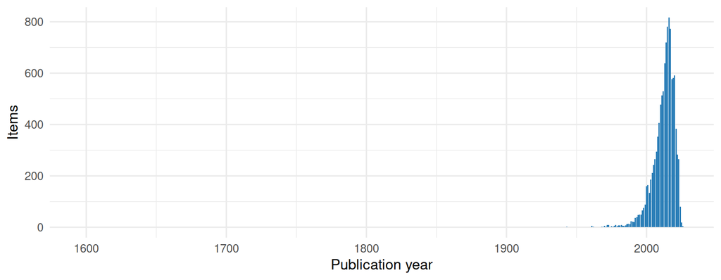

### Types of items

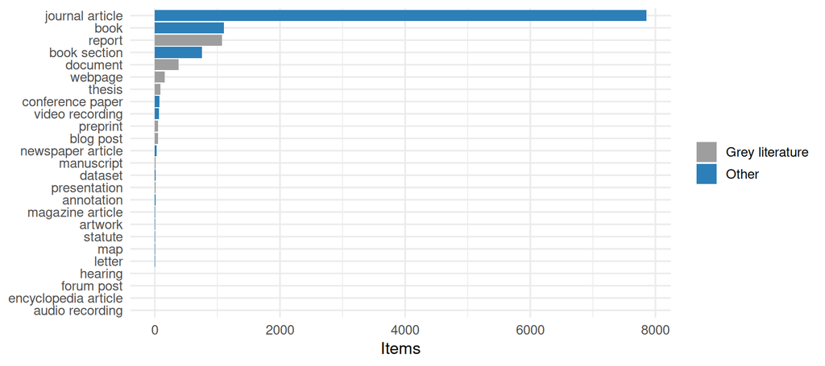

### Open access

Open access status of the publications found in OpenAlex. *Gold* and *diamond*: open in an open access journal; *hybrid*: open in a subscription journal; *green*: an open copy is in a repository; *bronze*: free to read on the publisher’s site; *closed*: not openly available.

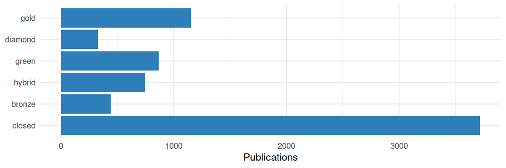

### Most frequent journals

| Journal | Items |
| --- | --- |
| Ecology and Society | 198 |
| Human Ecology | 119 |
| Journal of Ethnobiology and Ethnomedicine | 103 |
| Conservation Biology | 96 |
| Marine Policy | 96 |
| Biological Conservation | 95 |
| Ecological Economics | 87 |
| Global Environmental Change | 86 |
| World Development | 74 |
| Land Use Policy | 70 |

### Countries of the authors

Number of publications with at least one author from the country, for the publications found in OpenAlex.

| Country | Publications |
| --- | --- |
| United States | 2029 |
| United Kingdom | 1006 |
| Canada | 936 |
| Australia | 852 |
| Germany | 486 |
| Brazil | 455 |
| France | 403 |
| Spain | 367 |
| Netherlands | 355 |
| South Africa | 312 |
| India | 253 |
| Sweden | 251 |
| Italy | 242 |
| Mexico | 240 |
| Switzerland | 232 |

## How the checks work

**NoteDetails of the checks**

#### identifiers

##### DOI coverage (`met_id_doi`)

Number and share of items with a valid DOI, and items whose DOI field is filled but contains no valid DOI. DOIs are extracted with `openalexPro::extract_doi()` and lower cased.

##### ISBN coverage (`met_id_isbn`)

Number and share of items with an ISBN, overall and for the item types which should have one (`book`, `bookSection`).

##### ISSN coverage (`met_id_issn`)

Number and share of items with an ISSN, overall and for the item types which should have one (`journalArticle`, `magazineArticle`).

##### ISSN not in the standard form (`met_id_issn_form`)

Items whose ISSN field is not in the standard form: each ISSN as `1234-567X` (with hyphen, capital X), several separated by “,”. The ISSNs are checked with their check digit. If all are valid, the standard form is proposed; otherwise the item is listed with the ISSNs which are not valid.

##### DOIs in the wrong field (`met_id_doi_misplaced`)

Items with an empty DOI field but a DOI in the `Url` or `Extra` field. These DOIs are not used for the OpenAlex lookup and should be moved to the DOI field.

##### DOIs in the wrong form (`met_id_doi_form`)

Items whose DOI field contains a valid DOI, but not as a bare DOI: as a link (`https://doi.org/10.…`), with a prefix (`doi:`, `DOI`), URL-encoded (`%5B` for `[`) or with spaces or other characters around it. Citation styles add the link themselves, so a link in the DOI field appears twice in a bibliography. The bare DOI is the one recognised by `openalexPro::extract_doi()`, keeping its upper and lower case.

##### DOIs which do not exist (`met_id_doi_exists`)

Items whose DOI field contains a DOI in the right form which does not exist at doi.org: usually a typo, a shortened DOI, or a DOI with extra characters at the end (`.`, `;`, a link to supplementary material). Only DOIs which are not found in OpenAlex are checked at doi.org. Where the DOI without the extra characters at the end exists, it is given as suggestion.

##### Items without identifier (`met_id_none`)

Items with none of DOI, ISBN, ISSN or Url. These items can neither be checked against OpenAlex nor easily be retrieved by readers.

##### DOIs found in OpenAlex for items without a DOI (`met_id_candidates`)

For items without a DOI, OpenAlex was searched by title, and by the PubMed ID (line `PMID: …` in Extra), and Crossref by ISBN and title (see [get_doi_candidates()]).

#### metadata

##### Filled fields per item type (`met_meta_fields`)

Percentage of items with a filled field, per item type, for the main fields: Title, Author, Publication Year, Publication Title, Publisher, DOI, ISBN, ISSN, Url, Abstract Note and Language. Not every field is expected for every item type, e.g. reports have no Publication Title.

##### Problematic publication years (`met_meta_year`)

Items whose date is missing (`missing`), from whose date Zotero could not derive a year (`unparseable`), or whose year lies in the future (`future`).

##### Duplicate items (`met_meta_duplicates`)

Items which are in the group more than once, identified by the same DOI, or by the same normalised title (lower case, letters and digits only), publication year and first word of the first author.

##### Language not given as a standard code (`met_meta_language`)

Items whose language is not given as a standard language code, i.e. a two-letter ISO 639-1 code, optionally with a region (`en`, `en-US`), but e.g. as a name (`English`), a three-letter code (`eng`) or in a different spelling (`EN`, `en_us`). Citation styles and other tools only recognise the codes. Where the value is recognised, the standard code is proposed, based on the ISO 639-2 list (R package ISOcodes): codes, three-letter codes and the English names of the languages. Other values, e.g. names in the language itself, several languages or other text, are listed without a proposal.

#### openalex_check

##### Zotero DOIs found in OpenAlex (`met_check_found`)

Valid Zotero DOIs which were / were not found in OpenAlex. A DOI which is not found is either not indexed by OpenAlex or wrong (see `met_id_doi_exists` for DOIs which do not exist). DOIs of works which OpenAlex has under another DOI (e.g. the old and the new DOI of an article) count as found.

##### Retracted works (`met_check_retracted`)

Works flagged as retracted by OpenAlex, with the key of the Zotero item(s) with the same DOI.

##### Wrong DOIs (`met_check_mismatch`)

Items whose DOI points in OpenAlex to a work with a different title or year, which usually means that the wrong DOI is attached to the item. An item is flagged when the title similarity (normalised Levenshtein distance) is below 0.8 or the years differ by more than one. Items with the line `DOI checked: correct` in Extra (someone checked that the DOI is right, e.g. a book chapter with the DOI of the book, or a wrong year in OpenAlex) are not listed.

##### Item type agreement (`met_check_type`)

Zotero item type compared with the OpenAlex work type for items with the same DOI.

##### Missing dates found in OpenAlex (`met_check_date`)

Items without a date whose DOI was found in OpenAlex: the publication date in OpenAlex is proposed. OpenAlex gives 1 January when only the year is known, so such dates are proposed as the year only. Items whose DOI points to a different publication are left out.

##### Empty fields found in OpenAlex (`met_check_fill`)

Journal articles with an empty journal, volume, issue or pages field whose DOI was found in OpenAlex with these details: the values in OpenAlex are proposed. The journal is only taken if the publication is in a journal in OpenAlex (not e.g. a repository). Page ranges which end before they start (e.g. `1260-2`, shortened or wrong) are not proposed. Items whose DOI points to a different publication are left out.

##### Language differs from OpenAlex (`met_check_language`)

Items whose language in Zotero differs from the language of their DOI in OpenAlex. Only the language is compared, not the region (`en-US` and `en` are the same), and only for items whose language is given as a language code (see “Language not given as a language code”). Items without a language are listed under “No language”.

##### OpenAlex ID in the Extra field (`met_check_openalex_id`)

Items whose DOI was found in OpenAlex, compared with the OpenAlex ID noted in their Extra field (a line `OpenAlex: W…`). Items without such a line can get it, which links them to OpenAlex for later checks. Items with a different ID are listed for checking: OpenAlex merges records, and the ID of a merged record redirects to the new one. Items whose DOI points to a different publication are left out.

##### OpenAlex ID in the Extra field not valid (`met_check_extra_id`)

Checks the lines `OpenAlex: …` in the Extra field (looked up by [get_extra_ids()]). A line is not valid if - it is not an OpenAlex work ID (`W` and digits), - the item has several lines with different IDs, - the ID is not in OpenAlex (wrong, or merged into another record), or - the work is a different publication: its DOI is not the DOI of the item, or, for items without DOI, its title is not similar (similarity below 0.8, see [title_similarity()]).

#### profile

##### Publication years (`met_prof_year`)

Number of items per publication year, with cumulative counts. Items without a year are counted as `NA`.

##### Open access status (`met_prof_oa`)

OpenAlex open access status (gold, diamond, green, hybrid, bronze, closed) of the works, overall and per publication year.

##### Top journals (`met_prof_journals`)

The 50 most frequent journals, from the Publication Title in Zotero and the source of the primary location in OpenAlex. Ties at rank 50 are included.

##### Author countries (`met_prof_countries`)

Number of works with at least one author affiliated with an institution in a country, per country (ISO 3166-1 alpha-2 codes from OpenAlex).

##### Item types and grey literature (`met_prof_types`)

Number of items per item type (Zotero) or work type (OpenAlex), and the share of grey literature, i.e. reports, theses, dissertations, web pages, documents, presentations, manuscripts, blog posts and preprints.

##### Languages (`met_prof_language`)

Languages as entered, and normalised to two letter codes (lower case, region removed, English spellings mapped to `en`). Inconsistent codes in the language as entered are a quality issue in themselves.

#### maintenance

##### Group activity (`met_maint_activity`)

Items added per month, and items added / modified in the 30 days before the metrics were calculated.

##### Items without tags (`met_maint_tags`)

Items without manual tags. Automatic tags, e.g. keywords imported from the publisher, are ignored.

IPBES Literature Report 0.7.0 · [source code on GitHub](https://github.com/IPBES-Data/IPBES.LiteratureReport) (© IPBES.LiteratureReport authors, [MIT licence](https://opensource.org/license/mit)) · reports and data on this website: [CC0 1.0](https://creativecommons.org/publicdomain/zero/1.0/) (no rights reserved)